# OLS Regression with Truncated CenSoc Data

Casey Breen (caseybreen@berkeley.edu)

2020-07-25

**Summary**: This vignette presents a method for calculating mortality differentials using Ordinary Least Squares (OLS) regression on age at death. The goal of this vignette is to highlight the need for adjustment factors for interpreting OLS Regression coefficients when working with truncated data and work through a stylized example using this method to explore the relationship between wage income and longevity in the CenSoc-Numident dataset.

The original R notebook (.Rmd file) for this vignette can be downloaded [here](https://github.com/caseybreen/censocdev/tree/master/vignettes/website).

## Setup

```r
## Library Packages
library(tidyverse) ## Tools for data analysis
library(ipumsr)    ## Reads in IPUMS data
library(broom)     ## Cleans regression output
library(devtools)  ## R package development tools
library(data.table)## Tools for working with big data

## Set seed for reproducibility
set.seed(0.4886)

## Source some files from a GitHub Repository
devtools::source_url("https://github.com/caseybreen/numident_paper/blob/master/code/00_helper_functions.R?raw=TRUE")
```

## OLS Regression Truncation

Using OLS Regression on age of death with fixed effect terms for each year of birth is a straightforward method for analyzing CenSoc mortality data. There are a few specific considerations of using regression on age of death to analyze the CenSoc Mortality data. The CenSoc-Numident file only includes deaths occurring in the window of 1988-2005 (the period with high death coverage). As the left and right truncation ages vary by birth cohort, it is important to include fixed effect terms for each year of birth. Models of the form:

$$Age\_at\_death = birth\_year\_dummy + covariates\_of\_interest$$

As the truncated window of deaths excludes the tails of the mortality distribution, any measurement of the average difference between groups will be downwardly biased. Imagine there are two types of lobsters: red lobsters with an average weight of 5 lbs and blue lobsters with an average weight of 1 lb. Lobster fishers aren’t able to sell lobsters that are too small or too large — so they catch only lobsters between 2 and 3 pounds. If we just look at the lobsters that are caught, we’re observing only small red lobsters and big blue lobsters. If we compare the size of the caught lobsters, we would be understating the true difference in size between the red and blue lobsters. By the same logic, the coefficients in our OLS regression model will underestimate the size of the true effect.

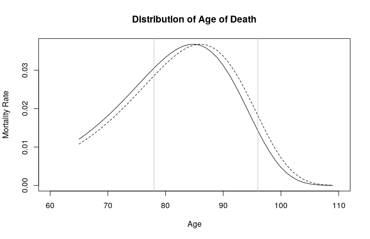

To account for this, we can calculate adjustment factors to help us more accurately interpret our regression coefficients. Users can do their full statistical analysis and then apply regression coefficients to help us better interpret our results.

## Calculating Regression Coefficient Adjustment Factors

We will step through calculating regression adjustment coefficients. First, we’ll decide upon the appropriate parameters for the Gompertz model — a popular old age mortality model. In general, we can just use default values to calculate our mortality parameters. The Gompertz parameters can be left at their default values of $\beta = 0.1$ and $M = 84$ unless there is a reason to override these values based on external estimates.

For demonstration purposes, in this vignette, we’ll use maximum likelihood estimation to calculate new Gompertz parameters from the birth cohort of 1910. We’ll then use simulation to calculate adjustment factors for this data set. For a more detailed discussion of this maximum likelihood estimation method, see the [“The Berkeley Unified Numident Mortality Database”](https://censoc.berkeley.edu/wp-content/uploads/2020/04/bunmd_paper.pdf) working paper.

```r
## Format data for maximum likelihood estimation
deaths_tabulated <- censoc_numident_demo %>%
  filter(byear %in% 1910) %>%
  group_by(death_age) %>%
  summarize(deaths = sum(weight)) %>%
  filter(death_age %in% 78:94) %>%
  tibble::deframe()

## Maximum Likelihood Estimation
x.left <- min(as.numeric(names(deaths_tabulated)))
x.right <- max(as.numeric(names(deaths_tabulated))) + 1

## Truncation
out <- counts.trunc.gomp.est(deaths_tabulated, x.left = x.left,
                             x.right = x.right,
                             b.start = 1/9, M.start = 80)

## Get Gompertz Parameters
(b.vec <- exp(out$par[1]))
(M.vec <- exp(out$par[2]))

## Get adjustment Factor
adjust.factor <- get.bunmd.adjust.factor(1905:1915,
                        M = M.vec,
                        b = b.vec,
                        N = 1000000)
```

```
#> [1] 0.09249799
#> [1] 84.30276
#> [1] "simulating: please be patient"
#> [1] "regressing: please continue to be patient"
#> [1] 3.1
```

## Mortality Differentials by Relative Wage Income

The association between relative wage income and mortality has been well-documented in the US. Can we see this association in our CenSoc-Numident dataset?

To answer this question, we’ll use the `INCWAGE` variable. This is an imperfect measure of income, as it was only collected for salary and wage workers. Census enumerators in 1940 were explicitly instructed to “not include earnings of businessmen, farmers, or professional persons who depend upon business profits, sales of crops, or fees for income and who do not work for wages or salaries.” (See [instructions to enumeration](https://usa.ipums.org/usa/voliii/inst1940.shtml#584) for more detail). In this analysis, we account for this by only including persons with non-zero wages — other researchers may take a different approach.

The CenSoc-Numident file is already restricted to deaths occurring in the “high-coverage” period of 1988-2005. We further restrict this analysis to the birth cohorts of 1905 to 1915 and deaths for persons 65+ (these are the birth cohorts and ages at death for which we have the best death coverage).

```r
## Calculate income deciles
## Restrict to cohorts of 1900-1920
censoc_incwage <- censoc_numident_demo %>%
  filter(byear %in% c(1905:1915)) %>%
  filter(dyear >= 65) %>%
  filter(INCWAGE > 0 & INCWAGE <= 5001) %>% ## INCWAGE is topcoded at $5001; higher values denote NA/Missing
  mutate(wage_decile = ntile(INCWAGE, 10)) %>%
  mutate(wage_decile = as.factor(wage_decile)) %>%
  mutate(educ_yrs = case_when(
  EDUCD== 2 ~ 0,
  EDUCD== 14 ~ 1,
  EDUCD== 15 ~ 2,
  EDUCD== 16 ~ 3,
  EDUCD== 17 ~ 4,
  EDUCD== 22 ~ 5,
  EDUCD== 23 ~ 6,
  EDUCD== 25 ~ 7,
  EDUCD== 26 ~ 8,
  EDUCD== 30 ~ 9,
  EDUCD== 40 ~ 10,
  EDUCD== 50 ~ 11,
  EDUCD== 60 ~ 12,
  EDUCD== 70 ~ 13,
  EDUCD== 80 ~ 14,
  EDUCD== 90 ~ 15,
  EDUCD== 100 ~ 16,
  EDUCD== 110 ~ 17
))

## Prepare data for model
censoc_incwage <- censoc_incwage %>%
  mutate(race_string = as_factor(RACE),
         bpl_string = as_factor(BPL),
         sex_string = as_factor(SEX),
         byear = as_factor(byear))

## print out variables for model
censoc_incwage %>%
  select(death_age, byear, sex_string, race_string, bpl_string, sex_string, educ_yrs) %>%
  sample_n(6)
```

| death_age | byear | sex_string | race_string | bpl_string | educ_yrs |
| --- | --- | --- | --- | --- | --- |
| 83 | 1914 | Male | White | Indiana | 8 |
| 86 | 1913 | Male | Black/African American | Mississippi | 4 |
| 79 | 1911 | Female | White | Maine | 12 |
| 78 | 1915 | Male | White | Tennessee | 12 |
| 73 | 1914 | Female | White | Massachusetts | 10 |
| 84 | 1915 | Male | White | Montana | 12 |

Here, we’ll run our regression and inflate our regression coefficients and standard errors by our adjustment factor of 3.1.

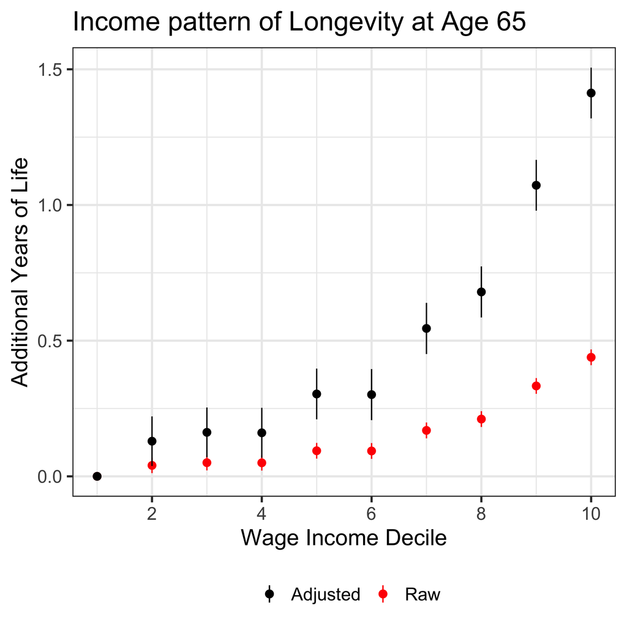

```r
## Run linear model
## Use both IPUMS and CenSoc weights
model <- lm(death_age ~  wage_decile +  byear + race_string + sex_string
                                    + educ_yrs + bpl_string,
                     data = censoc_incwage,
                     weight = weight)

## Put model results into a data.frame
model.df <- tidy(model, conf.int = T) %>%
  mutate(estimate_adj = estimate * adjust.factor,
         std.error_adj = std.error * adjust.factor)

## Select coefficients and standard errors from OLS model
model.df <- model.df %>%
  filter(str_detect(term, "wage_decile")) %>%
  mutate(quantile = as.numeric(substr(term, 12, 15))) %>%
  select(quantile, value = estimate, value_adj = estimate_adj, std.error, std.error_adj = std.error_adj) %>%
  add_row(quantile = 1, value = 0, std.error = 0, value_adj = 0, std.error_adj = 0)

## Plot
income_decile_ols_coefficients <- ggplot(data = model.df) +
  geom_pointrange(aes(ymin = value - std.error,
                      ymax = value + std.error,
                      y = value,
                      x = quantile,
                      color = "Raw")) +
  geom_pointrange(aes(ymin = value_adj - std.error_adj,
                      ymax = value_adj + std.error_adj,
                      y = value_adj,
                      x = quantile,
                      color = "Adjusted")
                  ) +
  theme_bw(base_size = 18) +
  labs(title = "Income pattern of Longevity at Age 65",
       x = "Wage Income Decile",
       y = "Additional Years of Life") +
  scale_x_continuous(breaks=seq(0,17,2)) +
  scale_color_manual(name = "", values = c("Adjusted" = "black", "Raw" = "red")) +
  theme(legend.position = "bottom")

ggsave(plot = income_decile_ols_coefficients, filename = "figures/income_decile_ols_coefficients.png")
```

## Conclusion

The CenSoc-Numident dataset allows researchers to explore broad patterns of mortality differentials in the United States. However, the truncated mortality distribution presents challenges for mortality estimation. To overcome this, we use OLS regression with adjustment factors to scale-up the magnitude of the regression coefficients to account for the downward bias caused by truncation.